# Age and year of entry of different immigrant groups

We show the age distributions of five important immigrant groups: Mexico, China, Cuba, India and Germany. These densities were computed by weghing observations using the survey weights PWGTP.

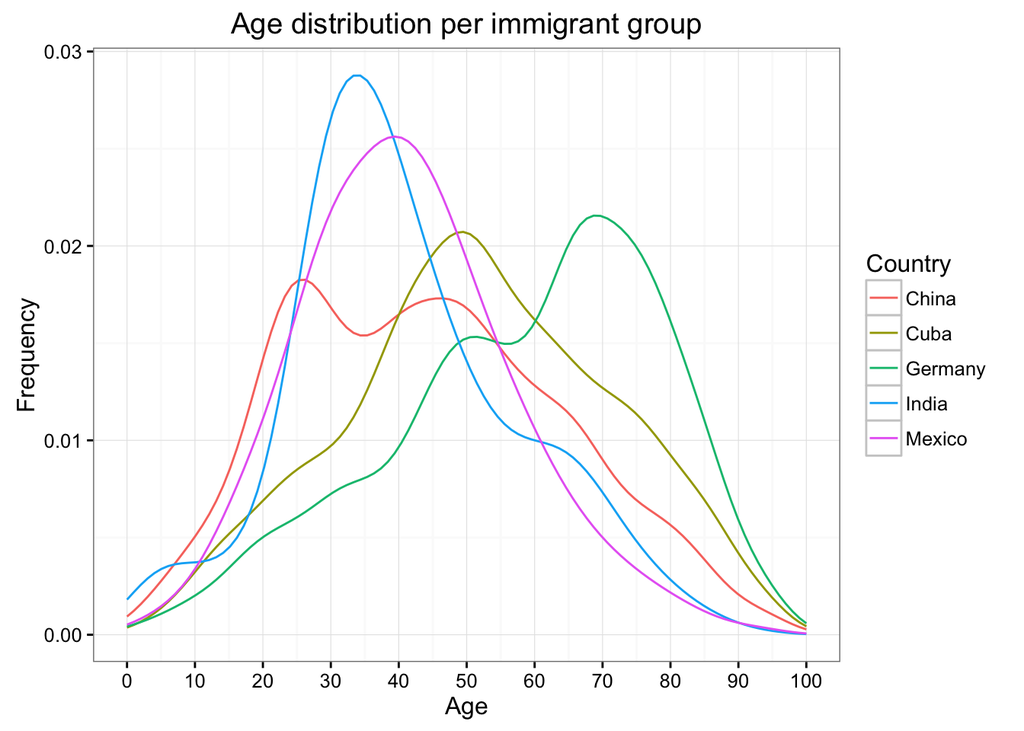

We notice that German immigrants tend to be significantly older than other groups, with a most likely age of about 70 years old. Cuban foreign-born residents are the second oldest group, with a typical age of about 50. In constrast, the bulk of Mexican and Indian immigrants tends to be in their thirties. Interestingly, the Chinese foreign-born population appears to have a bimodal distribution, with most idividuals either in their mid-twenties or in their forties.  
These age differences might be explained by the year in which each group entered the United States. We look at this next.

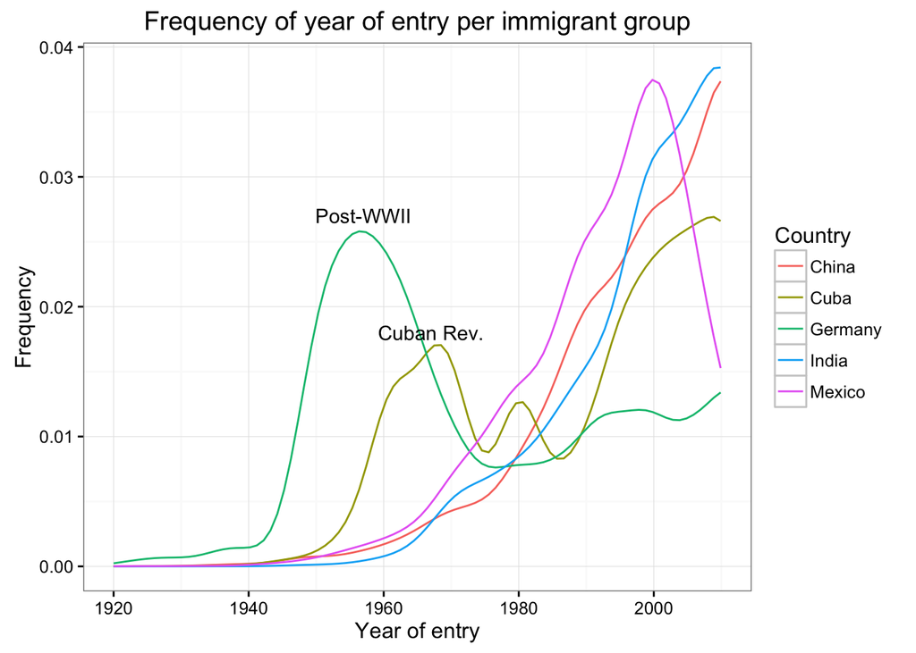

As suggested by the age distributions, we see that the large majority of the German group arrived in the coutry the earliest, in the two decades following World War II. The Cuban group followed, most likely pushed to exile by the revolution of 1953-59. We also see that the Mexican wave of immigration seems to have peaked around 2000, whereas Chinese and Indian immigration appears to not yet have reached its peak.  
Finally, we look at the distribution of the age of arrival, computed by subtracting the years since arrival (2014 - year-of-entry) to the current age.

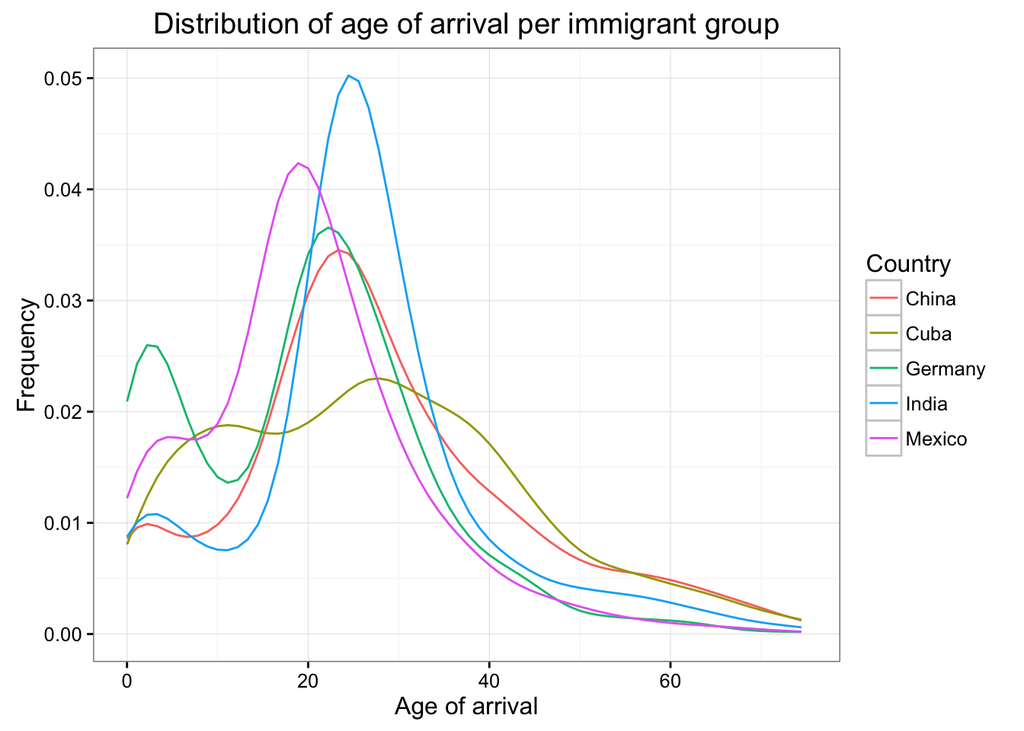

We see a general trend in most groups to immigrate to the country in their twenties. There is also evidence of a smaller mode at 0-10 years of age for most distributions, which suggests that a lot of foreign-born residents entered the country as small children.